# Data Analyst Job Postings Salary, Experience & Language Requirements

Exploratory visual report from a small sample of job postings

Ian Zablon Owuor

May 27, 2026

# Overview

This report explores a small sample of Data Analyst job postings, focusing on how **salary estimates** relate to **minimum experience requirements** and **data language requirements**.

Because this is a small sample and some fields were extracted from text, the results should be treated as **exploratory patterns**, not definitive labor-market conclusions.

The report includes two required visuals:

1. A scatter plot of **Minimum Years Experience** versus **Median Salary Estimate**.
2. A box plot of **Median Salary Estimate** grouped by **Data Languages**.

# Data Preparation

## Data Quality Snapshot

Distribution of postings by data language requirement after cleaning.

| Metric | Value |
| --- | --- |
| Rows in original dataset | 400 |
| Rows used in plots | 309 |
| Rows removed because salary or experience was missing/non-numeric | 91 |
| Median salary estimate | $68,000 |
| Median minimum years experience | 3 |

| Data Language Requirement | Number of Postings |
| --- | --- |
| R | 12 |
| Python | 49 |
| Both | 52 |
| Neither | 195 |
| Unknown | 1 |

# Experience and Salary

The scatter plot below shows each posting as a point. The x-axis represents the minimum years of experience requested, while the y-axis shows the median salary estimate.

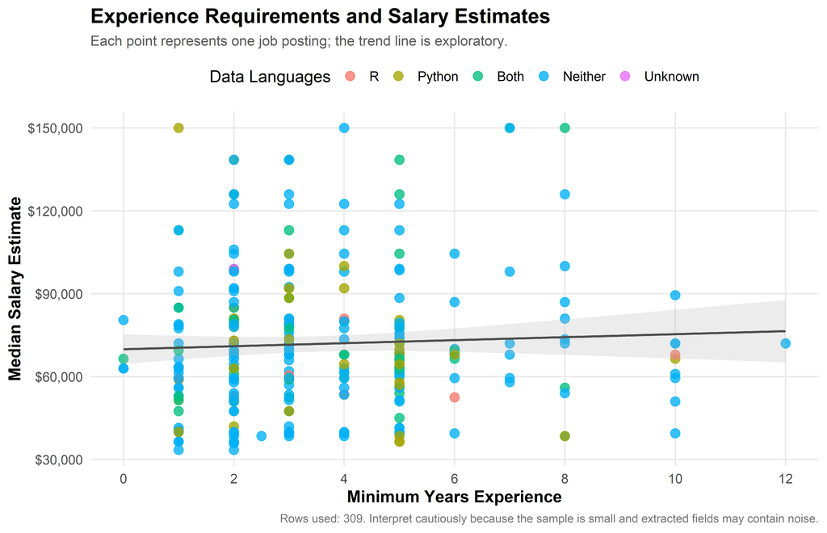

## Interpretation

The scatter plot provides an exploratory view of the relationship between experience requirements and salary estimates. A rising trend line would suggest that postings requiring more experience tend to offer higher salaries, but the amount of spread around the line matters: wide variation means experience alone does not explain salary differences.

In this sample, conclusions should be cautious because only 309 rows were available after cleaning. Salary may also be influenced by job title, company size, location, seniority wording, remote status, and other factors not shown in this chart.

# Salary by Data Language Requirement

The box plot below compares salary distributions across postings that mention different data language requirements.

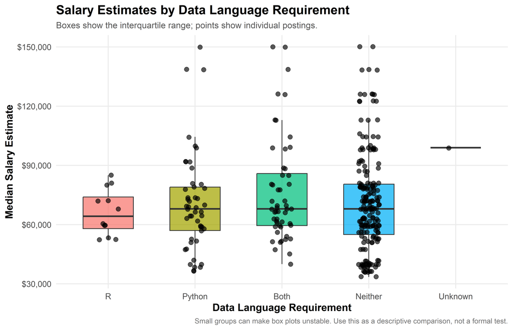

## Interpretation

The box plot compares the typical salary level and spread for each data language category. Higher median lines suggest higher typical salary estimates, while taller boxes or longer whiskers indicate more variation within that category.

Because some categories may contain only a few postings, the differences between groups should not be over-interpreted. A single high- or low-paying posting can strongly affect the apparent distribution when the sample size is small.

# Key Takeaways

Summary by data language requirement.

| data_languages | Postings | Median Salary | Median Experience |
| --- | --- | --- | --- |
| Neither | 195 | $68,000 | 3 |
| Both | 52 | $68,000 | 3 |
| Python | 49 | $68,000 | 3 |
| R | 12 | $64,250 | 3 |
| Unknown | 1 | $99,000 | 2 |

Overall, this report should be read as a polished exploratory analysis. The visuals are useful for identifying possible patterns, but a larger dataset would be needed to support stronger claims about the Data Analyst job market.

**Limitations:** This report uses extracted job-posting fields. Non-numeric experience values, missing salaries, inconsistent language labels, and small group sizes may affect the results.